# Topic 2-05: Use clusterProfiler for GSEA

Zuguang Gu z.gu@dkfz.de

2025-03-02

**Note in clusterProfiler, p-values are calculated by gene permutations!**

We use a dataset `gene_diff_score` which is a vector of a certain metric for differential expression of genes.

```r
gene_diff_score = readRDS(system.file("extdata", "gene_diff_score.rds", package = "GSEAtraining"))
head(gene_diff_score)
```

```
##    CDKN1A       BAX      MDM2      DDB2     STAT6     NTSR2
## 0.8425507 0.8232428 0.6306318 0.5945239 0.5791271 0.5712063
```

We need to convert genes from symbols to EntreZ IDs.

```r
library(org.Hs.eg.db)
map = mapIds(org.Hs.eg.db, keys = names(gene_diff_score), keytype = "SYMBOL", column = "ENTREZID")
head(map)
```

```
##  CDKN1A     BAX    MDM2    DDB2   STAT6   NTSR2
##  "1026"   "581"  "4193"  "1643"  "6778" "23620"
```

```r
# names(gene_diff_score) = map[ names(gene_diff_score) ]
```

For this dataset, the mapping is 1:1. But you need to be careful when the mapping is not 1:1.

Here we use the `convert_to_entrez_id()` function from the **GSEAtraining** package, which automatically takes care of multiple mappings:

```r
library(GSEAtraining)
gene_diff_score = convert_to_entrez_id(gene_diff_score)
```

```
##   gene id might be SYMBOL (p =  1.000 )
```

```r
head(gene_diff_score)
```

```
##          10         100        1000       10000       10001       10002
##  0.02683074  0.12681435 -0.13737449  0.13335944 -0.18805099  0.12855168
```

Load the **clusterProfiler** package.

```r
library(clusterProfiler)
```

Next we perform GSEA on different gene set sources.

Before we start, `gene_diff_score` must be pre-sorted.

```r
gene_diff_score = sort(gene_diff_score, decreasing = TRUE)
```

## GO enrichment

```r
library(org.Hs.eg.db)
tb = gseGO(geneList = gene_diff_score, ont = "BP", OrgDb = org.Hs.eg.db)
head(tb)
```

```
##                    ID                                               Description
## GO:1902850 GO:1902850 microtubule cytoskeleton organization involved in mitosis
## GO:0007059 GO:0007059                                    chromosome segregation
## GO:0006959 GO:0006959                                   humoral immune response
## GO:0002250 GO:0002250                                  adaptive immune response
## GO:0030001 GO:0030001                                       metal ion transport
## GO:0036503 GO:0036503                                              ERAD pathway
##            setSize enrichmentScore       NES       pvalue   p.adjust     qvalue
## GO:1902850      71      -0.4575756 -2.090862 1.372230e-05 0.01395839 0.01260456
## GO:0007059     163      -0.3325471 -1.780156 1.399197e-05 0.01395839 0.01260456
## GO:0006959     183       0.3792185  1.765310 1.241774e-05 0.01395839 0.01260456
## GO:0002250     287       0.3459634  1.686345 8.407636e-06 0.01395839 0.01260456
## GO:0030001     480       0.3110690  1.575450 1.004207e-05 0.01395839 0.01260456
## GO:0036503      38      -0.5403979 -2.150563 4.700469e-05 0.01465371 0.01323244
##            rank                   leading_edge
## GO:1902850 1730 tags=51%, list=26%, signal=38%
## GO:0007059 1730 tags=39%, list=26%, signal=29%
## GO:0006959 1855 tags=42%, list=28%, signal=31%
## GO:0002250 1536 tags=34%, list=23%, signal=28%
## GO:0030001 2101 tags=40%, list=31%, signal=30%
## GO:0036503 1955 tags=58%, list=29%, signal=41%
##                                                                                                                                                                                                                                                                                                          …
## GO:1902850                                                                                                                                                                                                                                                                                               …
## GO:0007059                                                                                                                                                                                                                                                                                               …
## GO:0006959                                                                                                                                                                                                                                                                                               …
## GO:0002250                                                                                                                                                                                                                                                                                               …
## GO:0030001 581/8912/2906/8514/150/7225/596/5371/3786/5027/3060/6524/655…
## GO:0036503                                                                                                                                                                                                                                                                                               …
```

## KEGG enrichment

```r
tb = gseKEGG(geneList = gene_diff_score, organism = "hsa")
head(tb)
```

```
##                ID                             Description setSize
## hsa04080 hsa04080 Neuroactive ligand-receptor interaction     234
## hsa03010 hsa03010                                Ribosome      85
## hsa04060 hsa04060  Cytokine-cytokine receptor interaction     193
## hsa04940 hsa04940                Type I diabetes mellitus      36
## hsa04081 hsa04081                       Hormone signaling     180
## hsa05332 hsa05332               Graft-versus-host disease      29
##          enrichmentScore      NES       pvalue     p.adjust       qvalue rank
## hsa04080       0.4047809 1.945879 3.962372e-08 1.311545e-05 1.101122e-05 2404
## hsa03010       0.5117854 2.145070 3.259659e-07 5.394735e-05 4.529210e-05 2348
## hsa04060       0.3930792 1.852082 3.335155e-06 3.679788e-04 3.089407e-04 1812
## hsa04940       0.5966921 2.102358 1.644226e-05 1.360597e-03 1.142305e-03 1530
## hsa04081       0.3760290 1.751671 4.550701e-05 3.012564e-03 2.529232e-03 1681
## hsa05332       0.6066064 2.041573 6.374356e-05 3.516520e-03 2.952333e-03 1762
##                            leading_edge
## hsa04080 tags=52%, list=36%, signal=35%
## hsa03010 tags=60%, list=35%, signal=40%
## hsa04060 tags=45%, list=27%, signal=34%
## hsa04940 tags=56%, list=23%, signal=43%
## hsa04081 tags=39%, list=25%, signal=30%
## hsa05332 tags=62%, list=26%, signal=46%
##                                                                                                                                                                                                                                                                                                          …
## hsa04080 23620/2906/150/2901/9248/2151/6870/7425/5027/3060/3362/4544/…
## hsa03010                                                                                                                                                                                                                                                                                                 …
## hsa04060                                                                                                                                                                 355/3439/9518/9466/1436/3552/3623/3565/8744/6357/7124/1896/9…
## hsa04940                                                                                                                                                                                                                                                                                                 …
## hsa04081                                                                                                                                                                                                                                                         2100/150/2980/3060/6714/6753/7432/1444/1…
## hsa05332                                                                                                                                                                                                                                                                                                 …
```

## Reactome enrichment

```r
library(ReactomePA)
tb = gsePathway(geneList = gene_diff_score, organism = "human")
```

```
## using 'fgsea' for GSEA analysis, please cite Korotkevich et al (2019).
```

```
## preparing geneSet collections...
```

```
## GSEA analysis...
```

```
## leading edge analysis...
```

```
## done...
```

```r
head(tb)
```

```
##                          ID                          Description setSize
## R-HSA-373076   R-HSA-373076 Class A/1 (Rhodopsin-like receptors)     197
## R-HSA-500792   R-HSA-500792                  GPCR ligand binding     267
## R-HSA-69278     R-HSA-69278                  Cell Cycle, Mitotic     275
## R-HSA-1640170 R-HSA-1640170                           Cell Cycle     347
## R-HSA-68886     R-HSA-68886                              M Phase     171
## R-HSA-9711097 R-HSA-9711097      Cellular response to starvation     103
##               enrichmentScore       NES       pvalue     p.adjust       qvalue
## R-HSA-373076        0.4374683  2.063703 3.562750e-09 1.203319e-06 9.788188e-07
## R-HSA-500792        0.3977675  1.942951 2.489766e-09 1.203319e-06 9.788188e-07
## R-HSA-69278        -0.3426571 -1.926699 3.547231e-09 1.203319e-06 9.788188e-07
## R-HSA-1640170      -0.3243844 -1.886042 1.726560e-09 1.203319e-06 9.788188e-07
## R-HSA-68886        -0.3744910 -2.010250 8.936594e-08 2.414668e-05 1.964169e-05
## R-HSA-9711097       0.4839274  2.080866 1.842829e-07 4.149436e-05 3.375286e-05
##               rank                   leading_edge
## R-HSA-373076  1666 tags=43%, list=25%, signal=33%
## R-HSA-500792  1681 tags=39%, list=25%, signal=31%
## R-HSA-69278   1565 tags=38%, list=23%, signal=30%
## R-HSA-1640170 1750 tags=39%, list=26%, signal=30%
## R-HSA-68886   1565 tags=40%, list=23%, signal=31%
## R-HSA-9711097 2290 tags=57%, list=34%, signal=38%
##                                                                                                                                                                                                                                                                                                          …
## R-HSA-373076                                                                                                                                                                                                                                                                                     23620/15…
## R-HSA-500792                                                                                                                                                                         23620/150/2151/6870/3060/3362/4544/2911/6357/6753/3351/6608/…
## R-HSA-69278                                                                                                                                                             4926/8317/11130/7443/10213/7514/140609/23636/9184/1875/1032/…
## R-HSA-1640170 1022/4171/5693/991/5347/6847/6119/472/5687/5520/10714/5433/6…
## R-HSA-68886                                                                                                                                                                                                                                                                                              …
## R-HSA-9711097                                                                                                                                                                                                                                                                                            …
```

## DO enrichment

```r
library(DOSE)
tb = gseDO(geneList = gene_diff_score)
```

```
## using 'fgsea' for GSEA analysis, please cite Korotkevich et al (2019).
```

```
## preparing geneSet collections...
```

```
## GSEA analysis...
```

```
## leading edge analysis...
```

```
## done...
```

```r
head(tb)
```

```
##                        ID                 Description setSize enrichmentScore
## DOID:10952     DOID:10952                   nephritis     174       0.3899824
## DOID:0050117 DOID:0050117 disease by infectious agent     372       0.3272434
## DOID:2914       DOID:2914       immune system disease     415       0.3146773
## DOID:2921       DOID:2921          glomerulonephritis     157       0.3962205
## DOID:3213       DOID:3213       demyelinating disease     106       0.4326570
## DOID:437         DOID:437           myasthenia gravis      10       0.8041483
##                   NES       pvalue    p.adjust      qvalue rank
## DOID:10952   1.805928 1.500537e-05 0.004346555 0.003696059 1461
## DOID:0050117 1.645332 6.146596e-06 0.004346555 0.003696059 1759
## DOID:2914    1.594663 1.057369e-05 0.004346555 0.003696059 1762
## DOID:2921    1.802314 3.017657e-05 0.006555859 0.005574723 1461
## DOID:3213    1.862278 5.306515e-05 0.009222724 0.007842471 1334
## DOID:437     2.050328 6.941254e-05 0.010053250 0.008548702 1041
##                                leading_edge
## DOID:10952   tags=36%, list=22%, signal=29%
## DOID:0050117 tags=36%, list=26%, signal=28%
## DOID:2914    tags=34%, list=26%, signal=27%
## DOID:2921    tags=37%, list=22%, signal=30%
## DOID:3213    tags=39%, list=20%, signal=31%
## DOID:437     tags=80%, list=16%, signal=68%
##                                                                                                                                                                                                                                                                                                          …
## DOID:10952                                                                                                                                                                                                                                                                                               …
## DOID:0050117                                                581/6778/355/6775/3439/174/259197/3565/6556/6608/7124/920/45…
## DOID:2914    1026/581/355/6775/2100/596/1436/3552/3060/3565/653361/1215/3…
## DOID:2921                                                                                                                                                                                                                                                                                                …
## DOID:3213                                                                                                                                                                                                                                                                                                …
## DOID:437                                                                                                                                                                                                                                                                                                 …
```

## MSigDB enrichment

There is no built-in function specific for MSigDB gene sets, but there is a universal function `GSEA()` which accepts manually-specified gene sets. The gene sets object is simply a two-column data frame:

- the first column is the gene set ID
- the second column is the gene ID

```r
library(msigdbr)
gene_sets = msigdbr(category = "H")
map = gene_sets[, c("gs_name", "entrez_gene")]
map$entrez_gene = as.character(map$entrez_gene)

tb = GSEA(geneList = gene_diff_score, TERM2GENE = map)
```

```
## using 'fgsea' for GSEA analysis, please cite Korotkevich et al (2019).
```

```
## preparing geneSet collections...
```

```
## GSEA analysis...
```

```
## leading edge analysis...
```

```
## done...
```

```r
head(tb)
```

```
##                                                        ID
## HALLMARK_G2M_CHECKPOINT           HALLMARK_G2M_CHECKPOINT
## HALLMARK_MITOTIC_SPINDLE         HALLMARK_MITOTIC_SPINDLE
## HALLMARK_ALLOGRAFT_REJECTION HALLMARK_ALLOGRAFT_REJECTION
## HALLMARK_E2F_TARGETS                 HALLMARK_E2F_TARGETS
## HALLMARK_UV_RESPONSE_DN           HALLMARK_UV_RESPONSE_DN
## HALLMARK_PROTEIN_SECRETION     HALLMARK_PROTEIN_SECRETION
##                                               Description setSize
## HALLMARK_G2M_CHECKPOINT           HALLMARK_G2M_CHECKPOINT     141
## HALLMARK_MITOTIC_SPINDLE         HALLMARK_MITOTIC_SPINDLE     116
## HALLMARK_ALLOGRAFT_REJECTION HALLMARK_ALLOGRAFT_REJECTION     168
## HALLMARK_E2F_TARGETS                 HALLMARK_E2F_TARGETS     129
## HALLMARK_UV_RESPONSE_DN           HALLMARK_UV_RESPONSE_DN     122
## HALLMARK_PROTEIN_SECRETION     HALLMARK_PROTEIN_SECRETION      80
##                              enrichmentScore       NES       pvalue
## HALLMARK_G2M_CHECKPOINT           -0.4118049 -2.148691 1.995936e-08
## HALLMARK_MITOTIC_SPINDLE          -0.3664304 -1.854935 2.954130e-05
## HALLMARK_ALLOGRAFT_REJECTION       0.3850893  1.801940 3.614303e-05
## HALLMARK_E2F_TARGETS              -0.3556870 -1.828188 6.632031e-05
## HALLMARK_UV_RESPONSE_DN           -0.3539525 -1.807871 1.233013e-04
## HALLMARK_PROTEIN_SECRETION        -0.3611194 -1.715185 1.611460e-03
##                                  p.adjust       qvalue rank
## HALLMARK_G2M_CHECKPOINT      9.979679e-07 7.983743e-07 1751
## HALLMARK_MITOTIC_SPINDLE     6.023838e-04 4.819070e-04 1717
## HALLMARK_ALLOGRAFT_REJECTION 6.023838e-04 4.819070e-04 1530
## HALLMARK_E2F_TARGETS         8.290039e-04 6.632031e-04 1740
## HALLMARK_UV_RESPONSE_DN      1.233013e-03 9.864106e-04 1557
## HALLMARK_PROTEIN_SECRETION   1.342883e-02 1.074306e-02 1369
##                                                leading_edge
## HALLMARK_G2M_CHECKPOINT      tags=46%, list=26%, signal=35%
## HALLMARK_MITOTIC_SPINDLE     tags=42%, list=26%, signal=32%
## HALLMARK_ALLOGRAFT_REJECTION tags=38%, list=23%, signal=30%
## HALLMARK_E2F_TARGETS         tags=40%, list=26%, signal=30%
## HALLMARK_UV_RESPONSE_DN      tags=38%, list=23%, signal=29%
## HALLMARK_PROTEIN_SECRETION   tags=32%, list=20%, signal=26%
##                                                                                                                                                                                                                                                                                                          …
## HALLMARK_G2M_CHECKPOINT      2176/4171/4678/991/5347/6558/7040/4926/8317/2130/4288/7514/3…
## HALLMARK_MITOTIC_SPINDLE                                                                                  6709/998/5347/2316/9771/2317/4926/23095/8476/10006/6654/1063…
## HALLMARK_ALLOGRAFT_REJECTION          355/6775/9466/3565/6223/6357/7124/920/3109/729230/43/8477/22…
## HALLMARK_E2F_TARGETS                                                                   4171/4678/991/5347/6119/10714/7884/4288/7514/3925/701/10527/…
## HALLMARK_UV_RESPONSE_DN                                                                                                    657/2869/8476/4325/140609/50937/7049/9112/3397/6541/4853/537…
## HALLMARK_PROTEIN_SECRETION                                                                                                                                                                                                    9367/9871/10059/5594/6197/23673/5868/1956/538/1182/8774/8027/9525/664/372/1…
```

## Example for other organism

1. GO enrichment

`gseGO()` accepts an `OrgDb` object as the source of the GO gene sets. We take pig as an example.

```r
library(org.Ss.eg.db)
all_genes = keys(org.Ss.eg.db, keytype = "ENTREZID")
scores = sort(rnorm(length(all_genes)), decreasing = TRUE)
names(scores) = sample(all_genes)
```

```r
tb = gseGO(geneList = scores, ont = "BP", OrgDb = org.Ss.eg.db, pvalueCutoff = 1)
head(tb)
```

```
##                    ID
## GO:0045747 GO:0045747
## GO:0070534 GO:0070534
## GO:0097120 GO:0097120
## GO:1901532 GO:1901532
## GO:0098732 GO:0098732
## GO:0032620 GO:0032620
##                                                            Description setSize
## GO:0045747              positive regulation of Notch signaling pathway      11
## GO:0070534                           protein K63-linked ubiquitination      26
## GO:0097120                            receptor localization to synapse      20
## GO:1901532 regulation of hematopoietic progenitor cell differentiation      11
## GO:0098732                                   macromolecule deacylation      11
## GO:0032620                                   interleukin-17 production      11
##            enrichmentScore       NES       pvalue  p.adjust    qvalue  rank
## GO:0045747       0.7759101  2.056429 0.0001896952 0.5747636 0.5747636  3621
## GO:0070534      -0.5904032 -1.965416 0.0005931794 0.5747636 0.5747636  7322
## GO:0097120      -0.6298791 -1.953420 0.0004218714 0.5747636 0.5747636  7728
## GO:1901532       0.7345371  1.946776 0.0009933622 0.5747636 0.5747636  3360
## GO:0098732       0.7159010  1.897384 0.0017588722 0.5747636 0.5747636 10401
## GO:0032620      -0.7141287 -1.864731 0.0026402885 0.5747636 0.5747636  1391
##                              leading_edge
## GO:0045747  tags=45%, list=8%, signal=42%
## GO:0070534 tags=46%, list=16%, signal=39%
## GO:0097120 tags=45%, list=17%, signal=37%
## GO:1901532  tags=36%, list=7%, signal=34%
## GO:0098732 tags=73%, list=23%, signal=56%
## GO:0032620  tags=45%, list=3%, signal=44%
##                                                                                                              core_enrichment
## GO:0045747                                                                    100525462/100157978/733648/100154395/100620481
## GO:0070534 100511733/100511251/100513527/100524597/733673/100144528/100515940/100512077/100154191/100513840/100518514/396629
## GO:0097120                         100153199/100738874/100516124/100157883/100156029/100522015/100513882/100514718/100626077
## GO:1901532                                                                              100316849/100516343/396709/100518091
## GO:0098732                                   100514684/100512576/100518786/100524215/100144485/100511643/100152776/100516143
## GO:0032620                                                                    100155546/100155269/100511742/574053/100240743
```

2. KEGG enrichment

The KEGG code of a specific organism can be found at https://rest.kegg.jp/list/organism

```r
tb = gseKEGG(geneList = scores, organism = "ssc", pvalueCutoff = 1)
head(tb)
```

```
##                ID                                                Description
## ssc00430 ssc00430                         Taurine and hypotaurine metabolism
## ssc00603 ssc00603 Glycosphingolipid biosynthesis - globo and isoglobo series
## ssc00531 ssc00531                              Glycosaminoglycan degradation
## ssc01521 ssc01521                  EGFR tyrosine kinase inhibitor resistance
## ssc04912 ssc04912                                     GnRH signaling pathway
## ssc00561 ssc00561                                    Glycerolipid metabolism
##          setSize enrichmentScore       NES       pvalue   p.adjust     qvalue
## ssc00430      21       0.6280590  1.987173 0.0002562394 0.08737762 0.08388467
## ssc00603      17       0.5747361  1.705502 0.0092329763 0.48864747 0.46911364
## ssc00531      18       0.5632017  1.703148 0.0092515799 0.48864747 0.46911364
## ssc01521      78       0.3683224  1.581548 0.0053575222 0.48864747 0.46911364
## ssc04912      90       0.3616452  1.581261 0.0046822184 0.48864747 0.46911364
## ssc00561      61      -0.3782747 -1.557039 0.0146830521 0.48864747 0.46911364
##           rank                   leading_edge
## ssc00430  6530 tags=48%, list=14%, signal=41%
## ssc00603  7802 tags=41%, list=17%, signal=34%
## ssc00531  5639 tags=39%, list=12%, signal=34%
## ssc01521 12638 tags=40%, list=28%, signal=29%
## ssc04912 12191 tags=41%, list=27%, signal=30%
## ssc00561  5029 tags=33%, list=11%, signal=29%
##                                                                                                                                                                                                                                                                                                          …
## ssc00430                                                                                                                                                                                                                                                    100523568/100151788/100523562/100153304/39709…
## ssc00603                                                                                                                                                                                                                                                                                  100415928/10014…
## ssc00531                                                                                                                                                                                                                                                                                  100512880/10015…
## ssc01521                                                             100525045/100511937/397070/397536/733648/654328/100525120/10…
## ssc04912 100738118/100623661/397070/100157507/100152679/100192436/100…
## ssc00561                                                                                                                                             100624333/100514782/100625799/100526190/100170845/100156278/100233189/100155736/100623089/100152049/397629/100625953/100519533/100156632/100525303/1…
```

3. MSigDB

Use `msigdbr::msigdbr_species()` to see which organisms are supported.

```r
gene_sets = msigdbr(species = "pig", category = "H")
map = gene_sets[, c("gs_name", "entrez_gene")]
map$entrez_gene = as.character(map$entrez_gene)

tb = GSEA(geneList = scores, TERM2GENE = map, pvalueCutoff = 1)
```

```
## using 'fgsea' for GSEA analysis, please cite Korotkevich et al (2019).
```

```
## preparing geneSet collections...
```

```
## GSEA analysis...
```

```
## leading edge analysis...
```

```
## done...
```

```r
head(tb)
```

```
##                                                                      ID
## HALLMARK_WNT_BETA_CATENIN_SIGNALING HALLMARK_WNT_BETA_CATENIN_SIGNALING
## HALLMARK_BILE_ACID_METABOLISM             HALLMARK_BILE_ACID_METABOLISM
## HALLMARK_ESTROGEN_RESPONSE_LATE         HALLMARK_ESTROGEN_RESPONSE_LATE
## HALLMARK_PEROXISOME                                 HALLMARK_PEROXISOME
## HALLMARK_PI3K_AKT_MTOR_SIGNALING       HALLMARK_PI3K_AKT_MTOR_SIGNALING
## HALLMARK_IL2_STAT5_SIGNALING               HALLMARK_IL2_STAT5_SIGNALING
##                                                             Description setSize
## HALLMARK_WNT_BETA_CATENIN_SIGNALING HALLMARK_WNT_BETA_CATENIN_SIGNALING      42
## HALLMARK_BILE_ACID_METABOLISM             HALLMARK_BILE_ACID_METABOLISM     109
## HALLMARK_ESTROGEN_RESPONSE_LATE         HALLMARK_ESTROGEN_RESPONSE_LATE     192
## HALLMARK_PEROXISOME                                 HALLMARK_PEROXISOME     103
## HALLMARK_PI3K_AKT_MTOR_SIGNALING       HALLMARK_PI3K_AKT_MTOR_SIGNALING     103
## HALLMARK_IL2_STAT5_SIGNALING               HALLMARK_IL2_STAT5_SIGNALING     192
##                                     enrichmentScore       NES     pvalue
## HALLMARK_WNT_BETA_CATENIN_SIGNALING       0.3829186  1.442591 0.03970850
## HALLMARK_BILE_ACID_METABOLISM            -0.2928561 -1.336016 0.04579881
## HALLMARK_ESTROGEN_RESPONSE_LATE          -0.2605259 -1.288915 0.01942338
## HALLMARK_PEROXISOME                      -0.2816160 -1.280603 0.08264463
## HALLMARK_PI3K_AKT_MTOR_SIGNALING          0.2882462  1.278780 0.06756757
## HALLMARK_IL2_STAT5_SIGNALING             -0.2573105 -1.273007 0.05364807
##                                      p.adjust    qvalue  rank
## HALLMARK_WNT_BETA_CATENIN_SIGNALING 0.5430712 0.5373546  6962
## HALLMARK_BILE_ACID_METABOLISM       0.5430712 0.5373546  7799
## HALLMARK_ESTROGEN_RESPONSE_LATE     0.5430712 0.5373546  7406
## HALLMARK_PEROXISOME                 0.5430712 0.5373546  7536
## HALLMARK_PI3K_AKT_MTOR_SIGNALING    0.5430712 0.5373546  7348
## HALLMARK_IL2_STAT5_SIGNALING        0.5430712 0.5373546 12237
##                                                       leading_edge
## HALLMARK_WNT_BETA_CATENIN_SIGNALING tags=33%, list=15%, signal=28%
## HALLMARK_BILE_ACID_METABOLISM       tags=28%, list=17%, signal=24%
## HALLMARK_ESTROGEN_RESPONSE_LATE     tags=28%, list=16%, signal=24%
## HALLMARK_PEROXISOME                 tags=26%, list=17%, signal=22%
## HALLMARK_PI3K_AKT_MTOR_SIGNALING    tags=28%, list=16%, signal=24%
## HALLMARK_IL2_STAT5_SIGNALING        tags=35%, list=27%, signal=26%
##                                                                                                                                                                                                                                                                                                          …
## HALLMARK_WNT_BETA_CATENIN_SIGNALING                                                                                                                                                                                                                                                                      …
## HALLMARK_BILE_ACID_METABOLISM                                                                                                                                                                                                                                                                            …
## HALLMARK_ESTROGEN_RESPONSE_LATE                                                                                                                        397617/100522195/100513507/100520876/396811/100156262/100515…
## HALLMARK_PEROXISOME                                                                                                                                                                                                                                                                                      …
## HALLMARK_PI3K_AKT_MTOR_SIGNALING                                                                                                                                                                                                                                                                         …
## HALLMARK_IL2_STAT5_SIGNALING        396689/100152012/100524259/100521528/100512497/595121/100516…
```

## Examples for less well-studied organisms

### When an `OrgDb` object is avaiable

Taking dolphin as an example. Since `org_db` is an `OrgDb` object, we can directly use `gseGO()`:

```r
library(AnnotationHub)
ah = AnnotationHub()
org_db = ah[["AH118180"]]
```

```
## loading from cache
```

```r
all_genes = keys(org_db, keytype = "ENTREZID")
scores = sort(rnorm(length(all_genes)), decreasing = TRUE)
names(scores) = sample(all_genes)

tb = gseGO(geneList = scores, ont = "BP", OrgDb = org_db, pvalueCutoff = 1)
```

```
## using 'fgsea' for GSEA analysis, please cite Korotkevich et al (2019).
```

```
## preparing geneSet collections...
```

```
## GSEA analysis...
```

```
## leading edge analysis...
```

```
## done...
```

```r
head(tb)
```

```
##                    ID                                       Description setSize
## GO:0009617 GO:0009617                             response to bacterium      99
## GO:0034975 GO:0034975          protein folding in endoplasmic reticulum      11
## GO:0043297 GO:0043297                          apical junction assembly      27
## GO:0070830 GO:0070830                bicellular tight junction assembly      27
## GO:0030163 GO:0030163                         protein catabolic process     399
## GO:0032446 GO:0032446 protein modification by small protein conjugation     304
##            enrichmentScore       NES       pvalue  p.adjust    qvalue rank
## GO:0009617       0.4042645  1.803762 0.0001087217 0.2529953 0.2529953 5638
## GO:0034975      -0.7634676 -2.010315 0.0003148366 0.3663124 0.3663124 4494
## GO:0043297      -0.5599361 -1.952223 0.0009462078 0.4043870 0.4043870 5454
## GO:0070830      -0.5599361 -1.952223 0.0009462078 0.4043870 0.4043870 5454
## GO:0030163      -0.2652839 -1.444492 0.0005980020 0.4043870 0.4043870 5578
## GO:0032446      -0.2715850 -1.429663 0.0010426824 0.4043870 0.4043870 4580
##                              leading_edge
## GO:0009617 tags=34%, list=19%, signal=28%
## GO:0034975 tags=45%, list=16%, signal=38%
## GO:0043297 tags=44%, list=19%, signal=36%
## GO:0070830 tags=44%, list=19%, signal=36%
## GO:0030163 tags=26%, list=19%, signal=21%
## GO:0032446 tags=25%, list=16%, signal=22%
##                                                                                                                                                                                                                                                                                                          …
## GO:0009617                                                                                                                                                                                                                                                                                               …
## GO:0034975                                                                                                                                                                                                                                                                                               …
## GO:0043297                                                                                                                                                                                                                                                                                               …
## GO:0070830                                                                                                                                                                                                                                                                                               …
## GO:0030163 101338838/101333740/117312944/101324739/101337856/117309120/…
## GO:0032446                                                                                                                                                                                                                                                                     101317033/101326471/117310…
```

### gseKEGG() also supports many other orgainsms

```r
gseKEGG(geneList = scores, organism = ...)
```

### Manually construct the gene sets

We have introduced many ways to obtain gene sets for less well-studies organisms. The only thing to do here is to convert gene sets to a two-column data frame where gene sets are in the first column and genes are in the second column. Then use `GSEA()`.

```r
GSEA(geneList = scores, TERM2GENE = ...)
```

## Look at the `tb` object

We used the same variable name `tb` for the object returned by the various enrichment functions. They are all in the same format. It looks like a table, but be careful, it is actually not:

```r
class(tb)
```

```
## [1] "gseaResult"
## attr(,"package")
## [1] "DOSE"
```

```r
str(tb)
```

```
## Formal class 'gseaResult' [package "DOSE"] with 13 slots
##   ..@ result     :'data.frame':  2327 obs. of  11 variables:
##   .. ..$ ID             : chr [1:2327] "GO:0009617" "GO:0034975" "GO:0043297" "GO:0070830" ...
##   .. ..$ Description    : chr [1:2327] "response to bacterium" "protein folding in endoplasmic reticulum" "apical junction assembly" "bicellular tight junction assembly" ...
##   .. ..$ setSize        : int [1:2327] 99 11 27 27 399 304 11 28 28 258 ...
##   .. ..$ enrichmentScore: num [1:2327] 0.404 -0.763 -0.56 -0.56 -0.265 ...
##   .. ..$ NES            : num [1:2327] 1.8 -2.01 -1.95 -1.95 -1.44 ...
##   .. ..$ pvalue         : num [1:2327] 0.000109 0.000315 0.000946 0.000946 0.000598 ...
##   .. ..$ p.adjust       : num [1:2327] 0.253 0.366 0.404 0.404 0.404 ...
##   .. ..$ qvalue         : num [1:2327] 0.253 0.366 0.404 0.404 0.404 ...
##   .. ..$ rank           : num [1:2327] 5638 4494 5454 5454 5578 ...
##   .. ..$ leading_edge   : chr [1:2327] "tags=34%, list=19%, signal=28%" "tags=45%, list=16%, signal=38%" "tags=44%, list=19%, signal=36%" "tags=44%, list=19%, signal=36%" ...
##   .. ..$ core_enrichment: chr [1:2327] "101326934/101339245/101327408/101316111/101336603/101324400/101340023/101319774/101331085/101326055/101337451/1"| __truncated__ "101327182/117309615/109548786/101317288/101319260" "101337537/117308342/101336398/101318557/101338385/101332512/101326108/101319…
##   ..@ organism   : chr "Tursiops truncatus"
##   ..@ setType    : chr "BP"
##   ..@ geneSets   :List of 7236
##   .. ..$ GO:0000002: chr [1:10] "101315666" "101325920" "101326047" "101328885" ...
##   .. ..$ GO:0000012: chr [1:3] "101321216" "101324135" "101337120"
##   .. ..$ GO:0000018: chr [1:19] "101318518" "101319565" "101320448" "101320591" ...
##   .. ..$ GO:0000019: chr [1:2] "101321967" "101338373"
##   .. ..$ GO:0000022: chr [1:2] "101315654" "101328106"
##   .. ..$ GO:0000027: chr [1:33] "101315465" "101316856" "101319900" "101320222" ...
##   .. ..$ GO:0000028: chr [1:34] "101317415" "101318043" "101318467" "101318567" ...
##   .. ..$ GO:0000032: chr "101318382"
##   .. ..$ GO:0000038: chr [1:24] "101318721" "101319800" "101320860" "101321283" ...
##   .. ..$ GO:0000041: chr [1:87] "101315672" "101316332" "101316680" "101316885" ...
##   .. ..$ GO:0000045: chr [1:44] "101316021" "101316129" "101317161" "101317562" ...
##   .. ..$ GO:0000050: chr "101330533"
##   .. ..$ GO:0000052: chr [1:4] "101319666" "101331088" "101336349" "117313824"
##   .. ..$ GO:0000053: chr "101330533"
##   .. ..$ GO:0000054: chr [1:17] "101318918" "101319915" "101322461" "101323043" ...
##   .. ..$ GO:0000055: chr [1:9] "101323043" "101324936" "101332258" "101333049" ...
##   .. ..$ GO:0000056: chr [1:8] "101319915" "101323043" "101334636" "101335049" ...
##   .. ..$ GO:0000070: chr [1:69] "101315654" "101315716" "101316211" "101316537" ...
##   .. ..$ GO:0000075: chr [1:63] "101316695" "101316733" "101318624" "101319304" ...
##   .. ..$ GO:0000076: chr [1:13] "101316733" "101320717" "101320935" "101323238" ...
##   .. ..$ GO:0000077: chr [1:31] "101316733" "101319304" "101320252" "101320465" ...
##   .. ..$ GO:0000079: chr [1:38] "101316500" "101317117" "101319016" "101319831" ...
##   .. ..$ GO:0000082: chr [1:30] "101317117" "101317432" "101319577" "101320635" ...
##   .. ..$ GO:0000086: chr [1:34] "101316733" "101318219" "101318851" "101319304" ...
```

[output cut: 77 more lines]

```
##   .. ..- attr(*, "names")= chr [1:28931] "117309820" "117309107" "101315926" "101320562" ...
##   ..@ keytype    : chr "ENTREZID"
##   ..@ permScores : num[0 , 0 ]
##   ..@ params     :List of 6
##   .. ..$ pvalueCutoff : num 1
##   .. ..$ eps          : num 1e-10
##   .. ..$ pAdjustMethod: chr "BH"
##   .. ..$ exponent     : num 1
##   .. ..$ minGSSize    : num 10
##   .. ..$ maxGSSize    : num 500
##   ..@ gene2Symbol: chr(0)
##   ..@ readable   : logi FALSE
##   ..@ termsim    : num[0 , 0 ]
##   ..@ method     : chr(0)
##   ..@ dr         : list()
```

> In the ORA analysis by **clusterProfiler**, we mentioned using `tb@result` returns the full enrichment table. **But this is not the case for the GSEA anlaysis!**. In GSEA anlaysis by **clusterProfiler**, `tb@result` still returns the significant terms. Add `pvalueCutoff = 1` argument if you need the full table.

## Practice

#### Practice 1

The input for e.g. `gseGO()` is a vector of gene-level scores, thus what metric is used for measuring gene-level differentiation has impact on the GSEA analysis. Here you use the following four gene-level metrics, apply them with `gseGO()` (GO BP + human) and compare the GSEA results.

Here we use the `p53_expr.rds` dataset.

```r
lt = readRDS(system.file("extdata", "p53_expr.rds", package = "GSEAtraining"))
expr = lt$expr
condition = lt$condition
```

First convert gene IDs to EntreZ IDs for `expr`:

```r
mat = convert_to_entrez_id(expr)
```

```
##   gene id might be SYMBOL (p =  0.690 )
```

Then calculate the column indicies of WT and MUT

```r
ind_MUT = which(condition == "MUT")
ind_WT = which(condition == "WT")
```

The four gene-level metrics:

1. signal-to-noise ratio
2. t-value
3. log2 fold change
4. signed log10 p-values

They can be calculated as:

```r
s2n = apply(mat, 1, function(x) {
    x1 = x[ind_MUT]
    x2 = x[ind_WT]

    (mean(x1) - mean(x2))/(sd(x1) + sd(x2))
})

tvalue = apply(mat, 1, function(x) {
    x1 = x[ind_MUT]
    x2 = x[ind_WT]

    t.test(x1, x2)$statistic
})

log2fc = apply(mat, 1, function(x) {
    x1 = x[ind_MUT]
    x2 = x[ind_WT]

    log2(mean(x1)/mean(x2))
})

logp = apply(mat, 1, function(x) {
    x1 = x[ind_MUT]
    x2 = x[ind_WT]

    t = t.test(x1, x2)
    sign(t$statistic)*(-log10(t$p.value))
})
```

Now use these four numeric vectors to perform GSEA analysis (on GO BP gene sets).

#### Solution

First to sort all the numeric vectors:

```r
s2n = sort(s2n, decreasing = TRUE)
tvalue = sort(tvalue, decreasing = TRUE)
log2fc = sort(log2fc, decreasing = TRUE)
logp = sort(logp, decreasing = TRUE)
```

```r
tb1 = gseGO(geneList = s2n, ont = "BP", OrgDb = org.Hs.eg.db)
```

```
## using 'fgsea' for GSEA analysis, please cite Korotkevich et al (2019).
```

```
## preparing geneSet collections...
```

```
## GSEA analysis...
```

```
## leading edge analysis...
```

```
## done...
```

```r
tb2 = gseGO(geneList = tvalue, ont = "BP", OrgDb = org.Hs.eg.db)
```

```
## using 'fgsea' for GSEA analysis, please cite Korotkevich et al (2019).
```

```
## preparing geneSet collections...
```

```
## GSEA analysis...
```

```
## leading edge analysis...
```

```
## done...
```

```r
tb3 = gseGO(geneList = log2fc, ont = "BP", OrgDb = org.Hs.eg.db)
```

```
## using 'fgsea' for GSEA analysis, please cite Korotkevich et al (2019).
```

```
## preparing geneSet collections...
```

```
## GSEA analysis...
```

```
## leading edge analysis...
```

```
## done...
```

```r
tb4 = gseGO(geneList = logp, ont = "BP", OrgDb = org.Hs.eg.db)
```

```
## using 'fgsea' for GSEA analysis, please cite Korotkevich et al (2019).
```

```
## preparing geneSet collections...
```

```
## GSEA analysis...
```

```
## leading edge analysis...
```

```
## done...
```

Get the “real data frames” for all terms.

```r
tb1 = tb1@result
tb2 = tb2@result
tb3 = tb3@result
tb4 = tb4@result
```

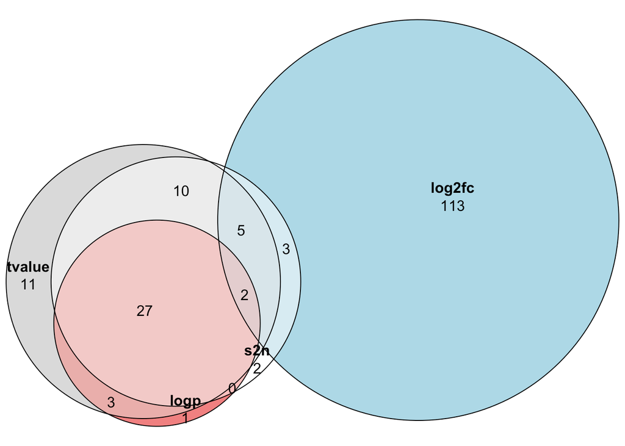

```r
library(eulerr)
plot(euler(list("s2n" = tb1$ID[tb1$p.adjust < 0.05],
                "tvalue" = tb2$ID[tb2$p.adjust < 0.05],
                "log2fc" = tb3$ID[tb3$p.adjust < 0.05],
                "logp" = tb4$ID[tb4$p.adjust < 0.05])),
    quantities = TRUE)
```

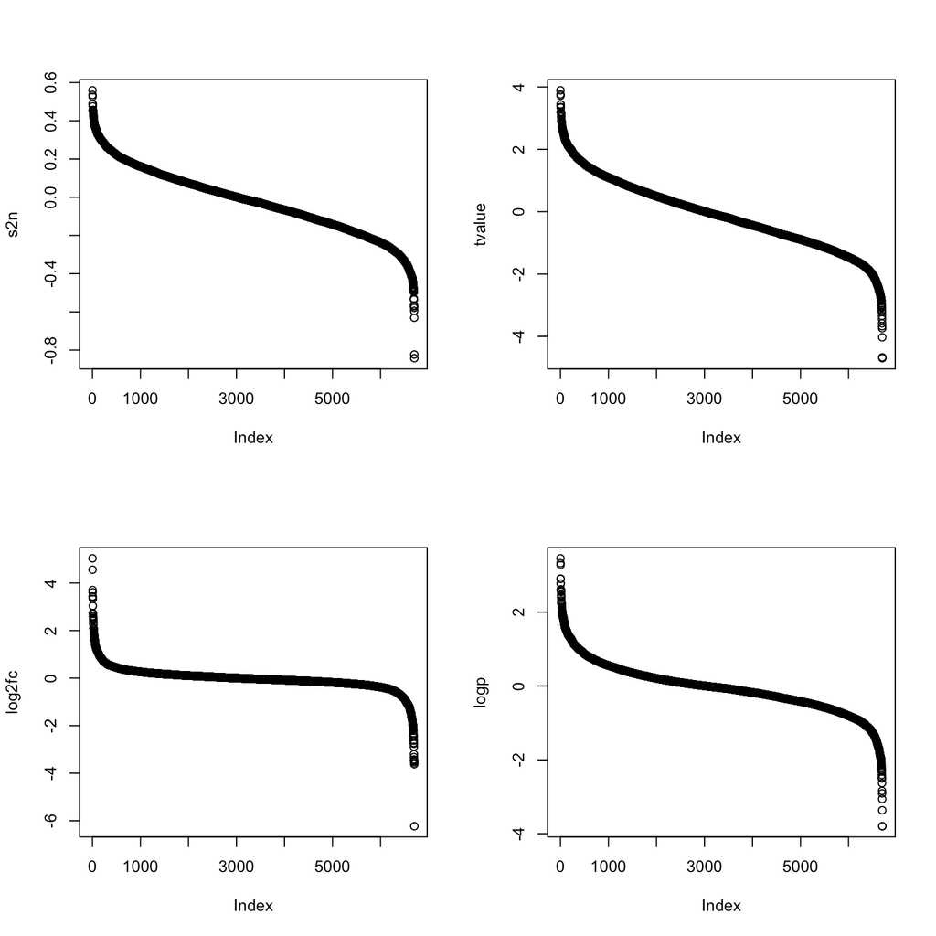

```r
par(mfrow = c(2, 2))
plot(s2n)
plot(tvalue)
plot(log2fc)
plot(logp)
```